# Homework 6

#### Part g

Use the following R code to simulate the sampling distribution of the sample mean for samples of size $n=50$. Calculate the mean and standard deviation of the salaries of the sampling distribution.

```r
sampling_dsn50 <- do(1000) * sample(mlb2016, size = 50) %>%
  summarise(mean = mean(Salary))

# Now calculate the mean and standard deviation
```

#### Part h

Below is a histogram of the simulated sampling distribution of the sample mean for samples of size $n=50$. Describe the distribution.

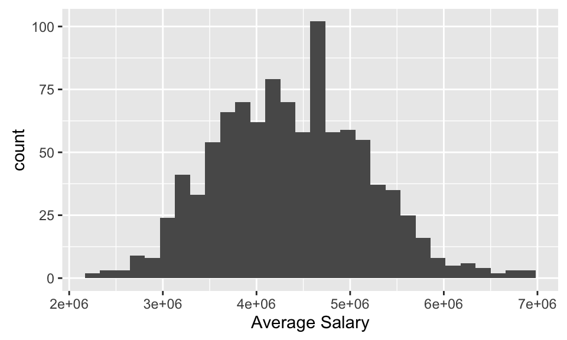

```r
ggplot(data = sampling_dsn50, mapping = aes(x = mean)) +
  geom_histogram() +
  labs(x = "Average Salary")
```

#### Part i

Use the following R code to simulate the sampling distribution of the sample mean for samples of size $n=100$. Calculate the mean and standard deviation of the salaries of the sampling distribution.

```r
sampling_dsn100 <- do(1000) * sample(mlb2016, size = 100) %>%
  summarise(mean = mean(Salary))

# Now calculate the mean and standard deviation
```

#### Part j

Below is a histogram of the simulated sampling distribution of the sample mean for samples of size $n=100$. Describe the distribution.

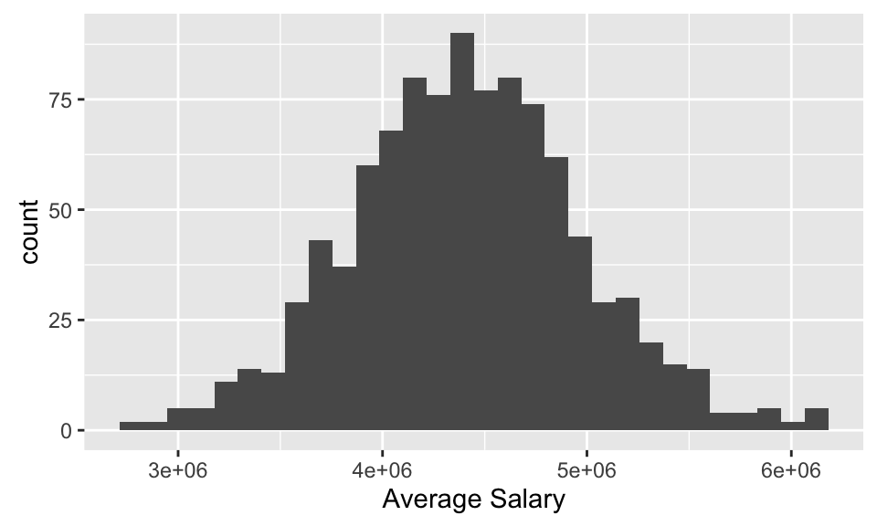

```r
ggplot(data = sampling_dsn100, mapping = aes(x = mean)) +
  geom_histogram() +
  labs(x = "Average Salary")
```

#### Part k

Compare the shapes of population distribution and the sampling distributions that you have simulated. Does the sample size impact the shape of the sampling distribution?

#### Part l

Compare the means of the sampling distributions that you have simulated. How do they compare to the population mean? How does the sample size impact the mean of the sampling distribution?

#### Part m

Compare the standard deviations (i.e. standard errors) of the sampling distributions that you have simulated. How do they compare to the population standard deviation? How does the sample size impact the standard error of the sampling distribution?